# STAT420-Group113 : Analysis of New York `Energy-Star` rating using linear regression

Rohit Bansal (rbansal3), Manas Kumar Mukherjee (manaskm2)

8/02/2019

## Introduction

#### Motivation

In today’s world, global warming and pollution are two biggest threats for human existence. We wanted to apply our newly learned linear-regression skills to get meaningful insights using some real data related to these issues.

As part of our research, we found that there were some significant work done by the Mayor’s office of the New York city in order to improve the energy efficiency of buildings.

As per [NYC Sustainability site](https://www1.nyc.gov/site/sustainability/our-programs/buildings.page) “In most major cities in the US, transportation produces the bulk of emissions. In New York City, 68% of emissions come from buildings. Almost half of those emissions come from only 2% of buildings. To counter this, the city needs aggressive retrofits to make existing buildings more efficient.”

##### Objective

The objective is to use the energy data to build a model that can predict the Energy Star Score of a building and interpret the results to find the factors which influence the score.

#### Description of the dataset

The original dataset is taken from the Govt. of New York’s website.

- Website - https://www1.nyc.gov/site/sustainability/our-programs/buildings.page
- File ref - https://www1.nyc.gov/html/gbee/downloads/misc/nyc_benchmarking_disclosure_data_reported_in_2017.xlsb

This dataset represents the Public Disclosure of benchmarking data for energy consumed in 2016. It contains data for lots with a single building and campuses.

The data defination of the individual columns are mentioned in the following file. http://www.nyc.gov/html/gbee/downloads/misc/nyc_benchmarking_disclosure_data_definitions_2017.pdf

In this dataset, we’ll be using the `ENERGY STAR Score` as the response variable. We’re interested in building an accurate and interpretable linear regression model and in identifying significant `ENERGY STAR Score` predictors. There are `53` other columns in this dataset. From a very high-level overview, we think a few of the following columns might be useful predictors: `Year Built`, `Occupancy`, `Natural Gas Use (kBtu)`, `Water Required?` etc.

## Methods

#### - Step1: Data preparation

1a. High level data. Mention dimension

As the first step we will load the data and rename the variable names in order to remove the space in the variable name. Also, Since `ENERGY.STAR.Score` is the response variable, we removing the records where the `ENERGY.STAR.Score` is not available.

```r
nyc_data_original = read.csv('NYC-BuildingEnergyData-FromSite_original.csv')
names(nyc_data_original) = make.names(names(nyc_data_original), unique=TRUE)
nyc_data_original = subset(nyc_data_original, nyc_data_original$ENERGY.STAR.Score != "Not Available")
dim(nyc_data_original)
```

```
## [1] 9642   54
```

So the original data set has 9,642 observations and 54 variables.

- After observing the data, we found that the following variables are for informational and tracking purpose and does not have any relevance for our analysis. So we deleted these variables from our dataset.

Order Property.Id Property.Name Parent.Property.Id Parent.Property.Name BBL…10.digits NYC.Borough..Block.and.Lot..BBL..self.reported NYC.Building.Identification.Number..BIN. Address.1..self.reported. Address.2 Postal.Code Street.Number Street.Name Release.Date DOF.Benchmarking.Submission.Status List.of.All.Property.Use.Types.at.Property

```r
#First we have to rename the column names to remove the space in the column name


nyc_data_clean = subset(nyc_data_original, select = -c(Order, Property.Id, Property.Name, Parent.Property.Id,
                                                      Parent.Property.Name, BBL...10.digits, NYC.Borough..Block.and.Lot..BBL..self.reported,                                                                       NYC.Building.Identification.Number..BIN.,Address.1..self.reported., Address.2,                                                                               Postal.Code,Street.Number,Street.Name, Release.Date, DOF.Benchmarking.Submission.Status,
                                                      List.of.All.Property.Use.Types.at.Property))
dim(nyc_data_clean)
```

```
## [1] 9642   38
```

- After this we checked for null/not avialable data for variables.

```r
library(knitr)
number_of_columns = ncol(nyc_data_clean)

not_available_values = rep(0, number_of_columns)

ind = 1
for (col in names(nyc_data_clean)){
  not_available_values[ind] = round(mean(nyc_data_clean[,col]=="Not Available"),2)
  ind = ind + 1
}

data_frame = data.frame(column_names = names(nyc_data_clean), num_of_not_available = not_available_values)
dt = data_frame[order(-data_frame$num_of_not_available),]
kable(x = dt)
```

|  | column_names | num_of_not_available |
| --- | --- | --- |
| 21 | Fuel.Oil..1.Use..kBtu. | 1.00 |
| 25 | Diesel..2.Use..kBtu. | 1.00 |
| 24 | Fuel.Oil..5…6.Use..kBtu. | 0.96 |
| 8 | X3rd.Largest.Property.Use.Type | 0.92 |
| 9 | X3rd.Largest.Property.Use.Type…Gross.Floor.Area..ft.. | 0.92 |
| 26 | District.Steam.Use..kBtu. | 0.92 |
| 23 | Fuel.Oil..4.Use..kBtu. | 0.89 |
| 22 | Fuel.Oil..2.Use..kBtu. | 0.78 |
| 6 | X2nd.Largest.Property.Use.Type | 0.75 |
| 7 | X2nd.Largest.Property.Use…Gross.Floor.Area..ft.. | 0.75 |
| 14 | Metered.Areas…Water. | 0.39 |
| 35 | Water.Use..All.Water.Sources…kgal. | 0.32 |
| 36 | Water.Intensity..All.Water.Sources…gal.ft.. | 0.32 |
| 19 | Weather.Normalized.Site.Natural.Gas.Intensity..therms.ft.. | 0.15 |
| 28 | Weather.Normalized.Site.Natural.Gas.Use..therms. | 0.15 |
| 17 | Weather.Normalized.Site.EUI..kBtu.ft.. | 0.11 |
| 20 | Weather.Normalized.Source.EUI..kBtu.ft.. | 0.11 |
| 27 | Natural.Gas.Use..kBtu. | 0.10 |
| 18 | Weather.Normalized.Site.Electricity.Intensity..kWh.ft.. | 0.05 |
| 30 | Weather.Normalized.Site.Electricity..kWh. | 0.05 |
| 29 | Electricity.Use…Grid.Purchase..kBtu. | 0.01 |
| 1 | Borough | 0.00 |
| 3 | Primary.Property.Type…Self.Selected | 0.00 |
| 4 | Largest.Property.Use.Type | 0.00 |
| 5 | Largest.Property.Use.Type…Gross.Floor.Area..ft.. | 0.00 |
| 10 | Year.Built | 0.00 |
| 11 | Number.of.Buildings…Self.reported | 0.00 |
| 12 | Occupancy | 0.00 |
| 13 | Metered.Areas..Energy. | 0.00 |
| 15 | ENERGY.STAR.Score | 0.00 |
| 16 | Site.EUI..kBtu.ft.. | 0.00 |
| 31 | Total.GHG.Emissions..Metric.Tons.CO2e. | 0.00 |
| 32 | Direct.GHG.Emissions..Metric.Tons.CO2e. | 0.00 |
| 33 | Indirect.GHG.Emissions..Metric.Tons.CO2e. | 0.00 |
| 34 | Property.GFA…Self.Reported..ft.. | 0.00 |
| 37 | Source.EUI..kBtu.ft.. | 0.00 |
| 38 | Water.Required. | 0.00 |
| 2 | DOF.Gross.Floor.Area | NA |

Based on the above table we found that following variables have missing data for more than more than 75% of observations.Also based on our domain knowledge these variables looks insignificant for our analysis. Thus we will not be considering these variables as well

- Fuel.Oil..1.Use..kBtu.
- Diesel..2.Use..kBtu.
- Fuel.Oil..5…6.Use..kBtu.
- X3rd.Largest.Property.Use.Type
- X3rd.Largest.Property.Use.Type…Gross.Floor.Area..ft..
- District.Steam.Use..kBtu.
- Fuel.Oil..4.Use..kBtu.
- Fuel.Oil..2.Use..kBtu.
- X2nd.Largest.Property.Use.Type
- X2nd.Largest.Property.Use…Gross.Floor.Area..ft..

```r
nyc_data_clean = subset(nyc_data_clean, select = -c(Fuel.Oil..1.Use..kBtu.,Diesel..2.Use..kBtu.,Fuel.Oil..5...6.Use..kBtu.,X3rd.Largest.Property.Use.Type,
                                                       X3rd.Largest.Property.Use.Type...Gross.Floor.Area..ft..,District.Steam.Use..kBtu.,
                                                       Fuel.Oil..4.Use..kBtu.,Fuel.Oil..2.Use..kBtu.,X2nd.Largest.Property.Use.Type,
                                                       X2nd.Largest.Property.Use...Gross.Floor.Area..ft..))
dim(nyc_data_clean)
```

```
## [1] 9642   28
```

```r
number_of_columns = ncol(nyc_data_clean)

not_available_values = rep(0, number_of_columns)

ind = 1
for (col in names(nyc_data_clean)){
  not_available_values[ind] = round(mean(nyc_data_clean[,col]=="Not Available"),2)
  ind = ind + 1
}

data_frame = data.frame(column_names = names(nyc_data_clean), num_of_not_available = not_available_values)
dt = data_frame[order(-data_frame$num_of_not_available),]
kable(x = dt)
```

|  | column_names | num_of_not_available |
| --- | --- | --- |
| 10 | Metered.Areas…Water. | 0.39 |
| 25 | Water.Use..All.Water.Sources…kgal. | 0.32 |
| 26 | Water.Intensity..All.Water.Sources…gal.ft.. | 0.32 |
| 15 | Weather.Normalized.Site.Natural.Gas.Intensity..therms.ft.. | 0.15 |
| 18 | Weather.Normalized.Site.Natural.Gas.Use..therms. | 0.15 |
| 13 | Weather.Normalized.Site.EUI..kBtu.ft.. | 0.11 |
| 16 | Weather.Normalized.Source.EUI..kBtu.ft.. | 0.11 |
| 17 | Natural.Gas.Use..kBtu. | 0.10 |
| 14 | Weather.Normalized.Site.Electricity.Intensity..kWh.ft.. | 0.05 |
| 20 | Weather.Normalized.Site.Electricity..kWh. | 0.05 |
| 19 | Electricity.Use…Grid.Purchase..kBtu. | 0.01 |
| 1 | Borough | 0.00 |
| 3 | Primary.Property.Type…Self.Selected | 0.00 |
| 4 | Largest.Property.Use.Type | 0.00 |
| 5 | Largest.Property.Use.Type…Gross.Floor.Area..ft.. | 0.00 |
| 6 | Year.Built | 0.00 |
| 7 | Number.of.Buildings…Self.reported | 0.00 |
| 8 | Occupancy | 0.00 |
| 9 | Metered.Areas..Energy. | 0.00 |
| 11 | ENERGY.STAR.Score | 0.00 |
| 12 | Site.EUI..kBtu.ft.. | 0.00 |
| 21 | Total.GHG.Emissions..Metric.Tons.CO2e. | 0.00 |
| 22 | Direct.GHG.Emissions..Metric.Tons.CO2e. | 0.00 |
| 23 | Indirect.GHG.Emissions..Metric.Tons.CO2e. | 0.00 |
| 24 | Property.GFA…Self.Reported..ft.. | 0.00 |
| 27 | Source.EUI..kBtu.ft.. | 0.00 |
| 28 | Water.Required. | 0.00 |
| 2 | DOF.Gross.Floor.Area | NA |

While loading the csv, quite a few variables were converted to factor variables as the data was numeric but contained “Not Available” for some records. Converting those recods back to the numeric variable

```r
nyc_data_clean$Water.Intensity..All.Water.Sources...gal.ft.. = as.numeric(as.character(nyc_data_clean$Water.Intensity..All.Water.Sources...gal.ft..))
nyc_data_clean$Source.EUI..kBtu.ft.. = as.numeric(as.character(nyc_data_clean$Source.EUI..kBtu.ft..))
nyc_data_clean$Water.Use..All.Water.Sources...kgal. = as.numeric(as.character(nyc_data_clean$Water.Use..All.Water.Sources...kgal.))
nyc_data_clean$Largest.Property.Use.Type...Gross.Floor.Area..ft.. = as.numeric(as.character(nyc_data_clean$Largest.Property.Use.Type...Gross.Floor.Area..ft..))

nyc_data_clean$Site.EUI..kBtu.ft.. = as.numeric(as.character(nyc_data_clean$Site.EUI..kBtu.ft..))

nyc_data_clean$Weather.Normalized.Site.EUI..kBtu.ft.. = as.numeric(as.character(nyc_data_clean$Weather.Normalized.Site.EUI..kBtu.ft..))
nyc_data_clean$Weather.Normalized.Site.Electricity.Intensity..kWh.ft.. = as.numeric(as.character(nyc_data_clean$Weather.Normalized.Site.Electricity.Intensity..kWh.ft..))
nyc_data_clean$Weather.Normalized.Site.Natural.Gas.Intensity..therms.ft.. = as.numeric(as.character(nyc_data_clean$Weather.Normalized.Site.Natural.Gas.Intensity..therms.ft..))
nyc_data_clean$Weather.Normalized.Source.EUI..kBtu.ft.. = as.numeric(as.character(nyc_data_clean$Weather.Normalized.Source.EUI..kBtu.ft..))
nyc_data_clean$Natural.Gas.Use..kBtu. = as.numeric(as.character(nyc_data_clean$Natural.Gas.Use..kBtu.))
nyc_data_clean$Weather.Normalized.Site.Natural.Gas.Use..therms. = as.numeric(as.character(nyc_data_clean$Weather.Normalized.Site.Natural.Gas.Use..therms.))
```

```r
nyc_data_clean$Electricity.Use...Grid.Purchase..kBtu. = as.numeric(as.character(nyc_data_clean$Electricity.Use...Grid.Purchase..kBtu.))
nyc_data_clean$Weather.Normalized.Site.Electricity..kWh. = as.numeric(as.character(nyc_data_clean$Weather.Normalized.Site.Electricity..kWh.))
nyc_data_clean$Total.GHG.Emissions..Metric.Tons.CO2e. = as.numeric(as.character(nyc_data_clean$Total.GHG.Emissions..Metric.Tons.CO2e.))
nyc_data_clean$Direct.GHG.Emissions..Metric.Tons.CO2e. = as.numeric(as.character(nyc_data_clean$Direct.GHG.Emissions..Metric.Tons.CO2e.))
nyc_data_clean$Indirect.GHG.Emissions..Metric.Tons.CO2e. = as.numeric(as.character(nyc_data_clean$Indirect.GHG.Emissions..Metric.Tons.CO2e.))
nyc_data_clean[ nyc_data_clean$Water.Required. == "",]['Water.Required.'] = 'Yes'

str(nyc_data_clean)
```

```
## 'data.frame':    9642 obs. of  28 variables:
##  $ Borough                                                   : Factor w/ 7 levels "#N/A","Bronx",..: 4 4 3 3 6 4 4 4 4 4 ...
##  $ DOF.Gross.Floor.Area                                      : int  3693539 2230742 NA 212656 NA NA 179130 102150 NA 151666 ...
##  $ Primary.Property.Type...Self.Selected                     : Factor w/ 55 levels "Adult Education",..: 13 13 24 24 13 24 24 24 24 24 ...
##  $ Largest.Property.Use.Type                                 : Factor w/ 54 levels "Adult Education",..: 13 13 22 22 13 22 22 22 22 22 ...
##  $ Largest.Property.Use.Type...Gross.Floor.Area..ft..        : num  3889181 2971874 412503 162656 567517 ...
##  $ Year.Built                                                : int  1969 1932 1903 1903 1950 1939 1939 1939 1911 1911 ...
##  $ Number.of.Buildings...Self.reported                       : int  12 12 2 1 2 2 1 1 2 1 ...
##  $ Occupancy                                                 : int  100 100 100 100 100 100 100 100 100 100 ...
##  $ Metered.Areas..Energy.                                    : Factor w/ 8 levels "Another configuration",..: 8 8 8 8 8 8 8 8 8 1 ...
##  $ Metered.Areas...Water.                                    : Factor w/ 7 levels "Another configuration",..: 7 7 7 4 7 7 4 4 7 4 ...
##  $ ENERGY.STAR.Score                                         : Factor w/ 101 levels "1","10","100",..: 52 52 94 1 80 71 65 80 3 3 ...
##  $ Site.EUI..kBtu.ft..                                       : num  230 360 32 295 353 ...
##  $ Weather.Normalized.Site.EUI..kBtu.ft..                    : num  229 359 NA 317 NA ...
##  $ Weather.Normalized.Site.Electricity.Intensity..kWh.ft..   : num  24.8 8.3 7.5 5.8 32.2 3.5 4 2.6 6.1 6.8 ...
##  $ Weather.Normalized.Site.Natural.Gas.Intensity..therms.ft..: num  2.4 4.8 0 3 2.2 0 0 0 0.5 NA ...
##  $ Weather.Normalized.Source.EUI..kBtu.ft..                  : num  401 412 NA 374 NA ...
##  $ Natural.Gas.Use..kBtu.                                    : num  9.33e+08 1.43e+09 2.05e+06 4.75e+07 1.28e+08 ...
##  $ Weather.Normalized.Site.Natural.Gas.Use..therms.          : num  9330734 14322509 20472 512711 1255514 ...
##  $ Electricity.Use...Grid.Purchase..kBtu.                    : num  3.32e+08 8.63e+07 1.12e+07 3.48e+06 6.24e+07 ...
##  $ Weather.Normalized.Site.Electricity..kWh.                 : num  96261312 24550859 3249755 1004824 18295845 ...
##  $ Total.GHG.Emissions..Metric.Tons.CO2e.                    : num  55870 54430 1194 2847 13303 ...
##  $ Direct.GHG.Emissions..Metric.Tons.CO2e.                   : num  51016 77564 151 2524 7510 ...
##  $ Indirect.GHG.Emissions..Metric.Tons.CO2e.                 : num  4854 -23134 1043 323 5793 ...
##  $ Property.GFA...Self.Reported..ft..                        : int  3889181 2971874 432503 172656 567517 321464 204720 116744 189766 130629 ...
##  $ Water.Use..All.Water.Sources...kgal.                      : num  NA NA 22061 NA 9574 ...
##  $ Water.Intensity..All.Water.Sources...gal.ft..             : num  NA NA 51 NA 16.9 ...
##  $ Source.EUI..kBtu.ft..                                     : num  404.3 414.2 87.9 352.2 599.5 ...
##  $ Water.Required.                                           : Factor w/ 3 levels "","No","Yes": 2 2 3 3 2 3 3 3 3 3 ...
```

So without removing any observation we have cleaned our dataset to a good extent. Now lets do some more analysis on our data. This data is for all the building in New York City and their energy rating. The different type of buildings will have different energy consumption pattern and thus the model should be differnet for them. So lets analyze the range of values we have for the property type.

```r
sort(table(nyc_data_clean$Largest.Property.Use.Type),decreasing = TRUE)
```

```
##
##                              Multifamily Housing
##                                             7529
##                                           Office
##                                             1193
##                                            Hotel
##                                              215
##                       Non-Refrigerated Warehouse
##                                              159
##                                      K-12 School
##                                               98
##                         Residence Hall/Dormitory
##                                               97
##                            Senior Care Community
##                                               92
##                                     Retail Store
##                                               64
##                              Distribution Center
##                                               62
##            Hospital (General Medical & Surgical)
##                                               41
##                                   Medical Office
##                                               29
##                        Supermarket/Grocery Store
##                                               19
##                                 Financial Office
##                                               15
##                           Refrigerated Warehouse
##                                                9
##                                 Worship Facility
##                                                9
##                       Wholesale Club/Supercenter
##                                                4
##                                          Parking
##                                                3
##                                      Bank Branch
##                                                2
##                                       Courthouse
##                                                2
##                                  Adult Education
```

[output cut: 54 more lines]

```
##                                                0
## Repair Services (Vehicle, Shoe, Locksmith, etc.)
##                                                0
##                        Residential Care Facility
##                                                0
##                                       Restaurant
##                                                0
##                            Self-Storage Facility
##                                                0
##                              Social/Meeting Hall
##                                                0
##                                       Strip Mall
##                                                0
##              Urgent Care/Clinic/Other Outpatient
##                                                0
```

So more than 75% of the data is for “Multifamily Housing”. Next biggest category is “Office” with more than 10% of the record. Rest all the categories makes roughly around 10% of the data combined. So we will be categorizing the property types in 3 broad categories: —MultiFamilyHousing —Office —Others

We will add a dummy variable to do so.

```r
nyc_data_clean$building_type = ifelse(nyc_data_clean$Largest.Property.Use.Type == "Multifamily Housing", 'MultiFamilyHousing',
                                      ifelse(nyc_data_clean$Largest.Property.Use.Type =="Office", "Office", "Others"))

nyc_data_clean$building_type = as.factor(nyc_data_clean$building_type)
table(nyc_data_clean$building_type)
```

```
##
## MultiFamilyHousing             Office             Others
##               7529               1193                920
```

```r
str(nyc_data_clean)
```

```
## 'data.frame':    9642 obs. of  29 variables:
##  $ Borough                                                   : Factor w/ 7 levels "#N/A","Bronx",..: 4 4 3 3 6 4 4 4 4 4 ...
##  $ DOF.Gross.Floor.Area                                      : int  3693539 2230742 NA 212656 NA NA 179130 102150 NA 151666 ...
##  $ Primary.Property.Type...Self.Selected                     : Factor w/ 55 levels "Adult Education",..: 13 13 24 24 13 24 24 24 24 24 ...
##  $ Largest.Property.Use.Type                                 : Factor w/ 54 levels "Adult Education",..: 13 13 22 22 13 22 22 22 22 22 ...
##  $ Largest.Property.Use.Type...Gross.Floor.Area..ft..        : num  3889181 2971874 412503 162656 567517 ...
##  $ Year.Built                                                : int  1969 1932 1903 1903 1950 1939 1939 1939 1911 1911 ...
##  $ Number.of.Buildings...Self.reported                       : int  12 12 2 1 2 2 1 1 2 1 ...
##  $ Occupancy                                                 : int  100 100 100 100 100 100 100 100 100 100 ...
##  $ Metered.Areas..Energy.                                    : Factor w/ 8 levels "Another configuration",..: 8 8 8 8 8 8 8 8 8 1 ...
##  $ Metered.Areas...Water.                                    : Factor w/ 7 levels "Another configuration",..: 7 7 7 4 7 7 4 4 7 4 ...
##  $ ENERGY.STAR.Score                                         : Factor w/ 101 levels "1","10","100",..: 52 52 94 1 80 71 65 80 3 3 ...
##  $ Site.EUI..kBtu.ft..                                       : num  230 360 32 295 353 ...
##  $ Weather.Normalized.Site.EUI..kBtu.ft..                    : num  229 359 NA 317 NA ...
##  $ Weather.Normalized.Site.Electricity.Intensity..kWh.ft..   : num  24.8 8.3 7.5 5.8 32.2 3.5 4 2.6 6.1 6.8 ...
##  $ Weather.Normalized.Site.Natural.Gas.Intensity..therms.ft..: num  2.4 4.8 0 3 2.2 0 0 0 0.5 NA ...
##  $ Weather.Normalized.Source.EUI..kBtu.ft..                  : num  401 412 NA 374 NA ...
##  $ Natural.Gas.Use..kBtu.                                    : num  9.33e+08 1.43e+09 2.05e+06 4.75e+07 1.28e+08 ...
##  $ Weather.Normalized.Site.Natural.Gas.Use..therms.          : num  9330734 14322509 20472 512711 1255514 ...
##  $ Electricity.Use...Grid.Purchase..kBtu.                    : num  3.32e+08 8.63e+07 1.12e+07 3.48e+06 6.24e+07 ...
##  $ Weather.Normalized.Site.Electricity..kWh.                 : num  96261312 24550859 3249755 1004824 18295845 ...
##  $ Total.GHG.Emissions..Metric.Tons.CO2e.                    : num  55870 54430 1194 2847 13303 ...
##  $ Direct.GHG.Emissions..Metric.Tons.CO2e.                   : num  51016 77564 151 2524 7510 ...
##  $ Indirect.GHG.Emissions..Metric.Tons.CO2e.                 : num  4854 -23134 1043 323 5793 ...
##  $ Property.GFA...Self.Reported..ft..                        : int  3889181 2971874 432503 172656 567517 321464 204720 116744 189766 130629 ...
##  $ Water.Use..All.Water.Sources...kgal.                      : num  NA NA 22061 NA 9574 ...
##  $ Water.Intensity..All.Water.Sources...gal.ft..             : num  NA NA 51 NA 16.9 ...
##  $ Source.EUI..kBtu.ft..                                     : num  404.3 414.2 87.9 352.2 599.5 ...
##  $ Water.Required.                                           : Factor w/ 3 levels "","No","Yes": 2 2 3 3 2 3 3 3 3 3 ...
##  $ building_type                                             : Factor w/ 3 levels "MultiFamilyHousing",..: 3 3 1 1 3 1 1 1 1 1 ...
```

Lets change the response variable name and convert it into a numeric variable:

```r
names(nyc_data_clean)[names(nyc_data_clean) =='ENERGY.STAR.Score'] = 'Score'

nyc_data_clean$Score = as.numeric(nyc_data_clean$Score)
```

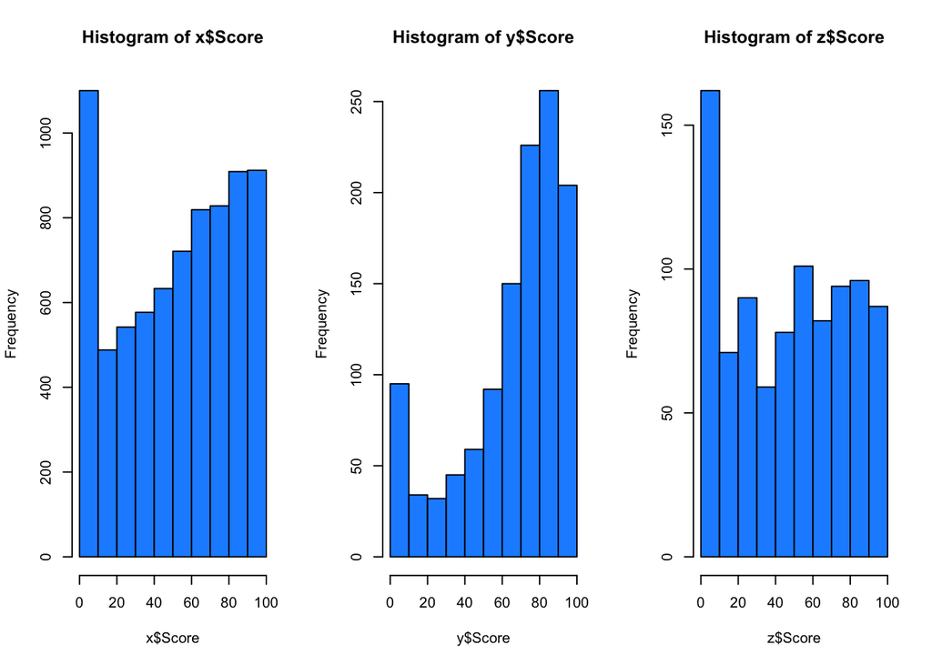

```r
par(mfrow = c(1,3))
x = nyc_data_clean[nyc_data_clean$building_type=="MultiFamilyHousing",]
y = nyc_data_clean[nyc_data_clean$building_type=="Office",]
z = nyc_data_clean[nyc_data_clean$building_type=="Others",]

hist(x$Score, col    = "dodgerblue")
hist(y$Score, col    = "dodgerblue")
hist(z$Score, col    = "dodgerblue")
```

1b. Remove unnessary variables based the data (null removal, imputation, row removal)

```r
names(nyc_data_clean)
```

```
##  [1] "Borough"
##  [2] "DOF.Gross.Floor.Area"
##  [3] "Primary.Property.Type...Self.Selected"
##  [4] "Largest.Property.Use.Type"
##  [5] "Largest.Property.Use.Type...Gross.Floor.Area..ft.."
##  [6] "Year.Built"
##  [7] "Number.of.Buildings...Self.reported"
##  [8] "Occupancy"
##  [9] "Metered.Areas..Energy."
## [10] "Metered.Areas...Water."
## [11] "Score"
## [12] "Site.EUI..kBtu.ft.."
## [13] "Weather.Normalized.Site.EUI..kBtu.ft.."
## [14] "Weather.Normalized.Site.Electricity.Intensity..kWh.ft.."
## [15] "Weather.Normalized.Site.Natural.Gas.Intensity..therms.ft.."
## [16] "Weather.Normalized.Source.EUI..kBtu.ft.."
## [17] "Natural.Gas.Use..kBtu."
## [18] "Weather.Normalized.Site.Natural.Gas.Use..therms."
## [19] "Electricity.Use...Grid.Purchase..kBtu."
## [20] "Weather.Normalized.Site.Electricity..kWh."
## [21] "Total.GHG.Emissions..Metric.Tons.CO2e."
## [22] "Direct.GHG.Emissions..Metric.Tons.CO2e."
## [23] "Indirect.GHG.Emissions..Metric.Tons.CO2e."
## [24] "Property.GFA...Self.Reported..ft.."
## [25] "Water.Use..All.Water.Sources...kgal."
## [26] "Water.Intensity..All.Water.Sources...gal.ft.."
## [27] "Source.EUI..kBtu.ft.."
## [28] "Water.Required."
## [29] "building_type"
```

```r
write.csv(nyc_data_clean, "nyc_data_clean.csv")
```

```r
#1
table(nyc_data_clean$building_type)
```

```
##
## MultiFamilyHousing             Office             Others
##               7529               1193                920
```

```r
#2
table(nyc_data_clean$Water.Required.)
```

```
##
##        No  Yes
##    0 3318 6324
```

```r
  #     No  Yes
  # 81 3318 6243
```

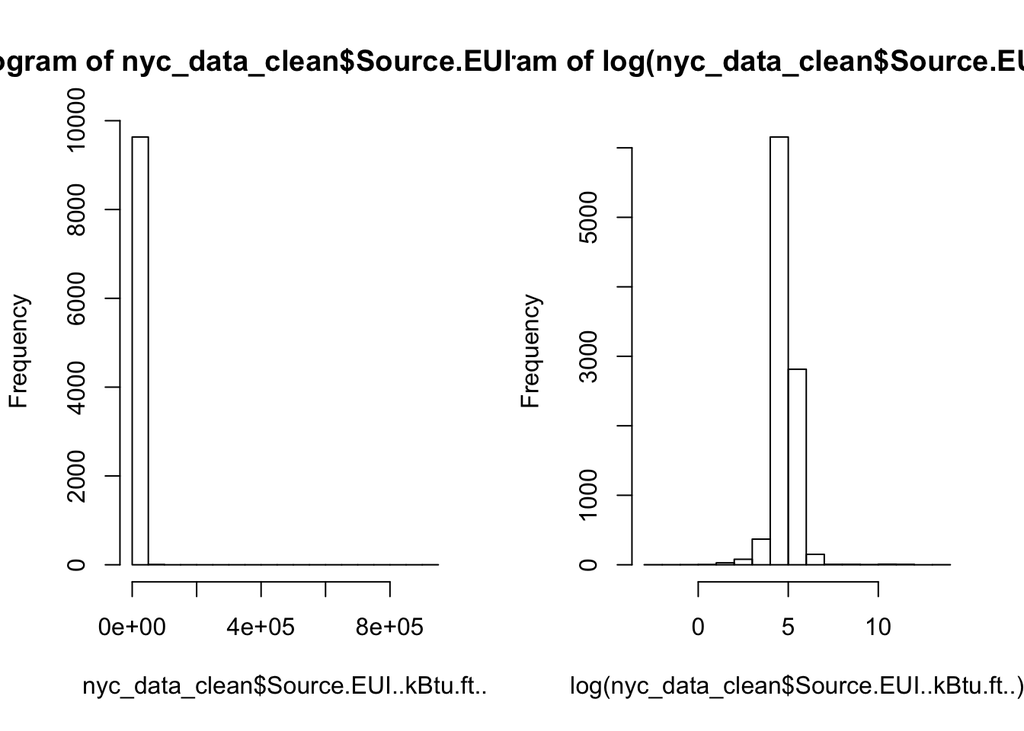

```r
#change factor to numeric(min-max scaler)
#3
nyc_data_clean$Source.EUI..kBtu.ft.. = as.numeric(nyc_data_clean$Source.EUI..kBtu.ft..)

par(mfrow = c(1,2))
hist(nyc_data_clean$Source.EUI..kBtu.ft..)
hist(log(nyc_data_clean$Source.EUI..kBtu.ft..))
```

```r
#4
x = as.numeric(nyc_data_clean$Water.Intensity..All.Water.Sources...gal.ft..)
length(x)
```

```
## [1] 9642
```

```r
col = 'Water.Intensity..All.Water.Sources...gal.ft..'
round(mean(nyc_data_clean[,col]=="Not Available"),4)
```

```
## [1] NA
```

```r
9642 * 0.323
```

```
## [1] 3114.366
```

```r
#nyc_data_clean[which(nyc_data_clean$Water.Intensity..All.Water.Sources...gal.ft.. == "Not Available"), ]

nyc_data_clean$Water.Intensity..All.Water.Sources...gal.ft.. = ifelse(nyc_data_clean$Water.Intensity..All.Water.Sources...gal.ft..=="Not Available",0, as.numeric(nyc_data_clean$Water.Intensity..All.Water.Sources...gal.ft..) )

write.csv(nyc_data_clean, "nyc_data_clean_1.csv")
aggregate(as.double(nyc_data_clean$Water.Intensity..All.Water.Sources...gal.ft..) ~ building_type, nyc_data_clean, mean)
```

```
##        building_type
## 1 MultiFamilyHousing
## 2             Office
## 3             Others
##   as.double(nyc_data_clean$Water.Intensity..All.Water.Sources...gal.ft..)
## 1                                                               103.39159
## 2                                                                42.79896
## 3                                                               232.34960
```

```r
# DOF.Gross.Floor.Area : 63
nrow(nyc_data_clean[which(nyc_data_clean$DOF.Gross.Floor.Area == "NA"), ])
```

```
## [1] 0
```

```r
nyc_data_clean$DOF.Gross.Floor.Area[1:10]
```

```
##  [1] 3693539 2230742      NA  212656      NA      NA  179130  102150
##  [9]      NA  151666
```

```r
ifelse(is.na(nyc_data_clean$DOF.Gross.Floor.Area), 0, as.numeric(nyc_data_clean$DOF.Gross.Floor.Area))[1:10]
```

```
##  [1] 3693539 2230742       0  212656       0       0  179130  102150
##  [9]       0  151666
```

```r
nrow(nyc_data_clean[which(nyc_data_clean$Year.Built == 0), ])
```

```
## [1] 0
```

```r
range01 = function(x){(x-min(x))/(max(x)-min(x))}

# min-max scaler
#par(mfrow=c(1,2))
#hist(nyc_data_clean$Year.Built)
#hist(range01(nyc_data_clean$Year.Built))
```

```r
# Number.of.Buildings...Self.reported
#hist(nyc_data_clean$Number.of.Buildings...Self.reported)
#hist(log(nyc_data_clean$Number.of.Buildings...Self.reported))

range01 = function(x){(x-min(x))/(max(x)-min(x))}

scaled_value = range01(nyc_data_clean$Number.of.Buildings...Self.reported)
nyc_data_clean$Number.of.Buildings...Self.reported = scaled_value
```

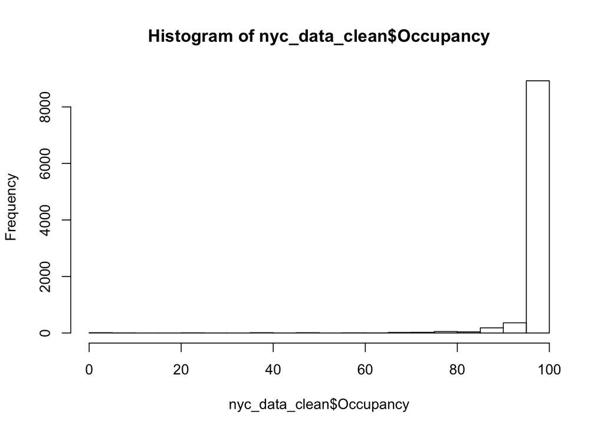

```r
#Occupancy
hist(nyc_data_clean$Occupancy)
```

```r
scaled_value = range01(nyc_data_clean$Occupancy)
nyc_data_clean$Occupancy = scaled_value
```

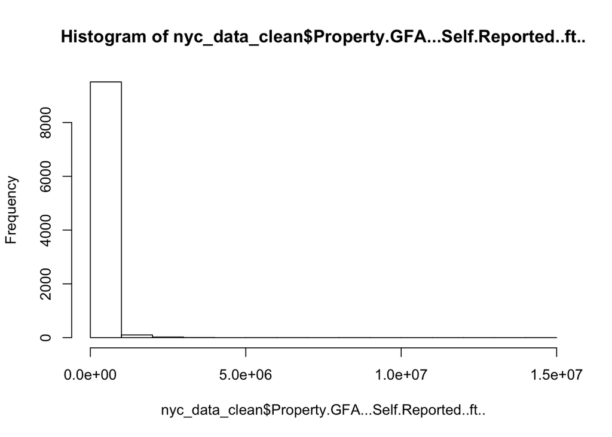

```r
hist(nyc_data_clean$Property.GFA...Self.Reported..ft..)
```

```r
scaled_value = range01(nyc_data_clean$Property.GFA...Self.Reported..ft..)
nyc_data_clean$Property.GFA...Self.Reported..ft.. = scaled_value
```

## Appendix

There are standard models used by Govt. We can compare our model with those standard models.